# How to make sweet lollipop plots!

Julia Müller

1 December 2020

Lightning talk for [R-Ladies Freiburg’s](https://www.meetup.com/rladies-freiburg/) December 2020 meetup (“This year I learned… and it changed my life!”).

Inspiration for this (and many other plots I’ve made) courtesy of the [R Graph Gallery](https://www.r-graph-gallery.com/)

## What’s a lollipop plot?

Here’s an example:

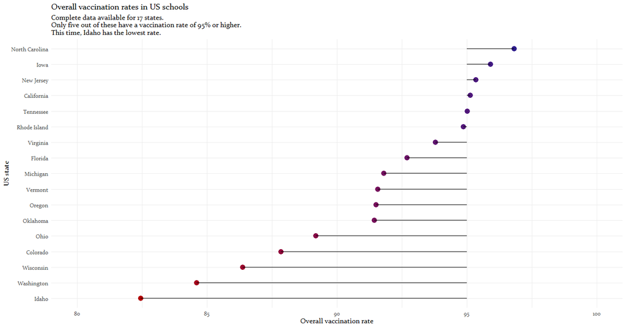

- similar to a bar plot, but:
  - consists of a line (“stem”) and a dot at the top (“marker”)
- variables to visualise:
  - one numeric
  - one categorical
  - plus optional additional variables (numeric or categorical)
- but consider that lollipop plots don’t show dispersion measures (e.g. standard deviation)

## How do I make one of these?

- using ggplot (what else)
- but there’s no separate geom for it
- instead, we’ll combine
  - geom_segments for the lines/stems
  - geom_point for the dots

## Data and packages

```r
chopped <- readr::read_tsv('https://raw.githubusercontent.com/rfordatascience/tidytuesday/master/data/2020/2020-08-25/chopped.tsv')

library(tidyverse)
library(viridis) # optional - for nice, colourblind-friendly colours
```

- this Tidy Tuesday dataset contains data on the cooking TV gameshow “Chopped”
- we’ll visualise the IMDB episode rating in a lollipop plot
- more info on this data [here](https://github.com/rfordatascience/tidytuesday/blob/master/data/2020/2020-08-25/readme.md)

## A tiny bit of data prep

We need to convert season and series_episode to factors, and drop NAs.

```r
chopped <- chopped %>%
  mutate(season = as_factor(season),
         series_episode = as_factor(series_episode)) %>%
  drop_na(episode_rating)

head(chopped)
```

```
## # A tibble: 6 x 21
##   season season_episode series_episode episode_rating episode_name episode_notes
##   <fct>           <dbl> <fct>                   <dbl> <chr>        <chr>
## 1 1                   1 1                         9.2 Octopus, Du~ This is the ~
## 2 1                   2 2                         8.8 Tofu, Blueb~ This is the ~
## 3 1                   3 3                         8.9 Avocado, Ta~ <NA>
## 4 1                   4 4                         8.5 Banana, Col~ In the appet~
## 5 1                   5 5                         8.8 Yucca, Wate~ <NA>
## 6 1                   6 6                         8.5 Canned Peac~ <NA>
## # ... with 15 more variables: air_date <chr>, judge1 <chr>, judge2 <chr>,
## #   judge3 <chr>, appetizer <chr>, entree <chr>, dessert <chr>,
## #   contestant1 <chr>, contestant1_info <chr>, contestant2 <chr>,
## #   contestant2_info <chr>, contestant3 <chr>, contestant3_info <chr>,
## #   contestant4 <chr>, contestant4_info <chr>
```

## First plot!

We’ll only visualise ratings from the first four seasons in order to not clutter the graph.

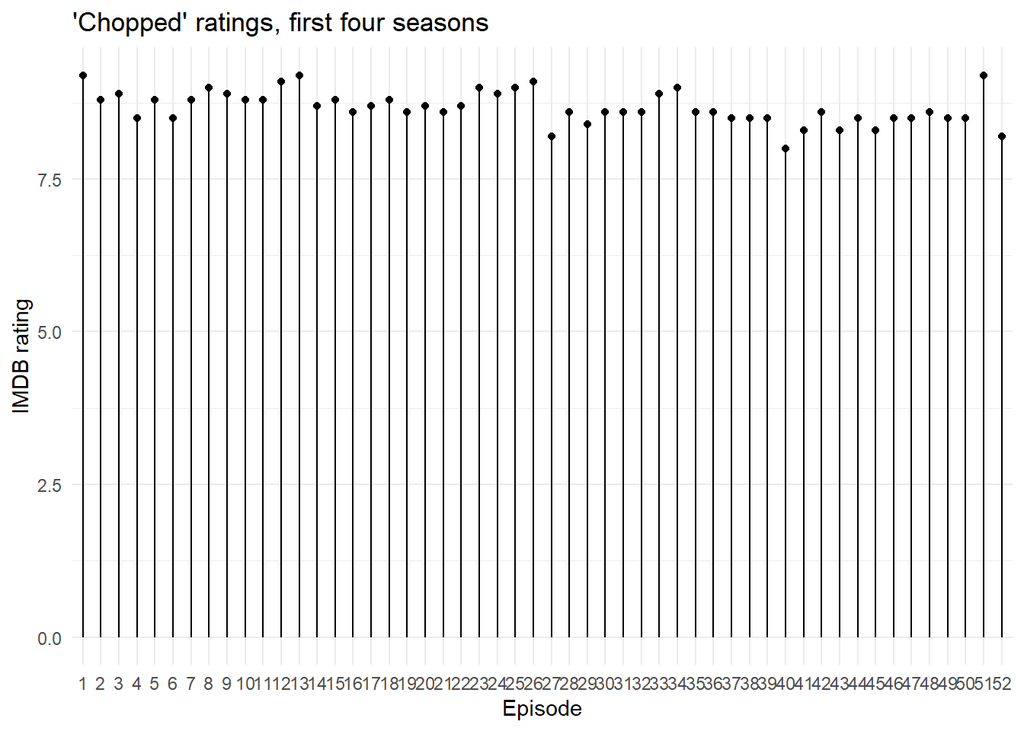

```r
chopped %>%
  filter(season %in% c("1", "2", "3", "4")) %>%
  ggplot() +
  aes(x = series_episode,
      y = episode_rating) +
  geom_point() + # dots
  geom_segment(aes(x = series_episode, xend = series_episode, # line drawn for each episode
                   y = 0, yend = episode_rating) # lines should start at 0 and end at the episode rating (i.e. connect with the dot)
               ) +
  theme_minimal() +
  labs(x = "Episode",
       y = "IMDB rating",
       title = "'Chopped' ratings, first four seasons")
```

## Changing the baseline

Which episodes get ratings of 9 or higher?

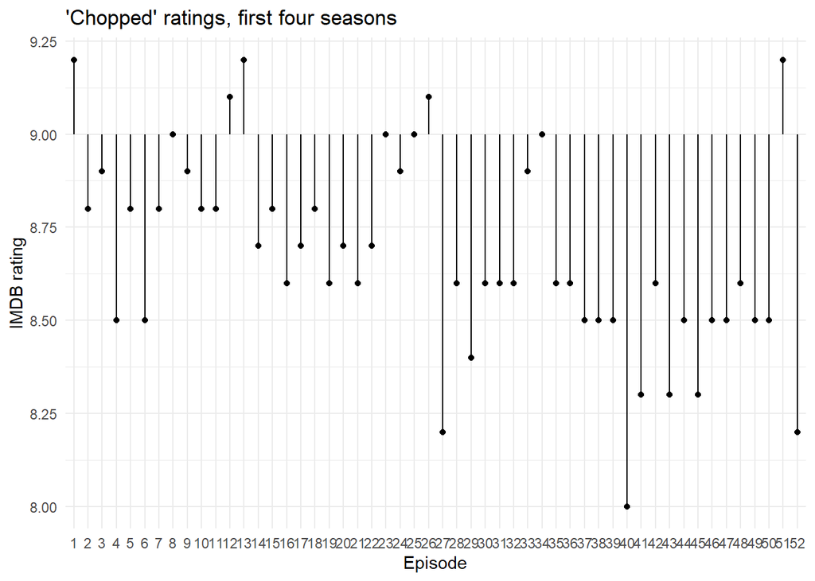

```r
chopped %>%
  filter(season %in% c("1", "2", "3", "4")) %>%
  ggplot() +
  aes(x = series_episode,
      y = episode_rating) +
  geom_point() +
  geom_segment(aes(x = series_episode, xend = series_episode,
                   y = 9, yend = episode_rating)
               ) +
  theme_minimal() +
  labs(x = "Episode",
       y = "IMDB rating",
       title = "'Chopped' ratings, first four seasons")
```

Which episodes have above-average, which have below-average ratings?

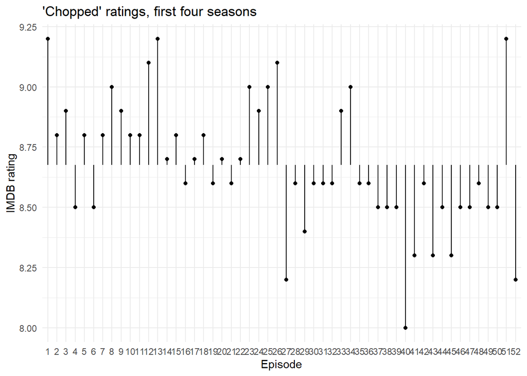

```r
chopped %>%
  filter(season %in% c("1", "2", "3", "4")) %>%
  ggplot() +
  aes(x = series_episode,
      y = episode_rating) +
  geom_point() +
  geom_segment(aes(x = series_episode, xend = series_episode,
                   y = mean(episode_rating), yend = episode_rating)
               ) +
  theme_minimal() +
  labs(x = "Episode",
       y = "IMDB rating",
       title = "'Chopped' ratings, first four seasons")
```

## Reordering

Let’s sort by rating instead of chronologically by episode using reorder. Adding a minus sorts in descending order, otherwise it’ll sort in ascending order.

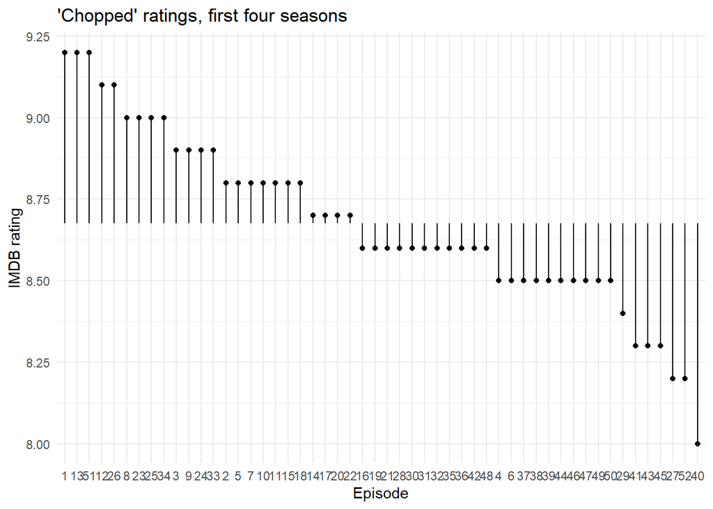

```r
chopped %>%
  filter(season %in% c("1", "2", "3", "4")) %>%
  ggplot() +
  aes(x = reorder(series_episode, -episode_rating),
      y = episode_rating) +
  geom_point() +
  geom_segment(aes(x = series_episode, xend = series_episode,
                   y = mean(episode_rating), yend = episode_rating)
               ) +
  theme_minimal() +
  labs(x = "Episode",
       y = "IMDB rating",
       title = "'Chopped' ratings, first four seasons")
```

## Labels

Let’s use the name of the episode instead of the number. For longer labels, it often makes sense to flip the coordinate system by adding + coord_flip().

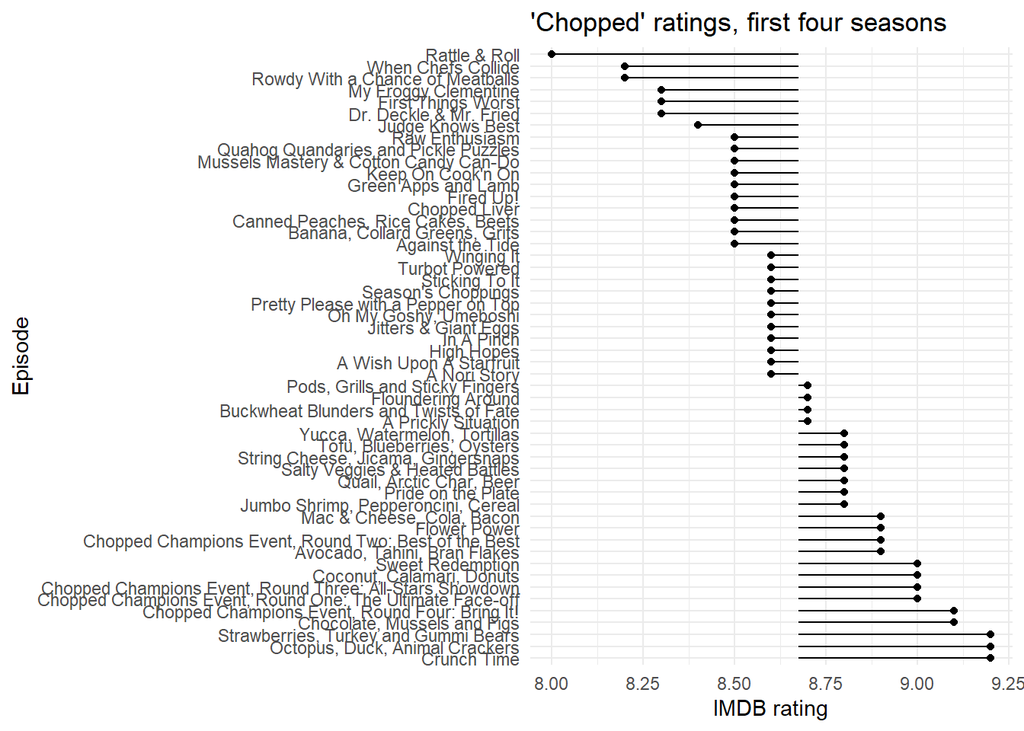

```r
chopped %>%
  filter(season %in% c("1", "2", "3", "4")) %>%
  ggplot() +
  aes(x = reorder(episode_name, -episode_rating),
      y = episode_rating) +
  geom_point() +
  geom_segment(aes(x = episode_name, xend = episode_name,
                   y = mean(episode_rating), yend = episode_rating)
               ) +
  theme_minimal() +
  labs(x = "Episode",
       y = "IMDB rating",
       title = "'Chopped' ratings, first four seasons") +
  coord_flip()
```

## Adding in colour

Let’s colour-code the seasons:

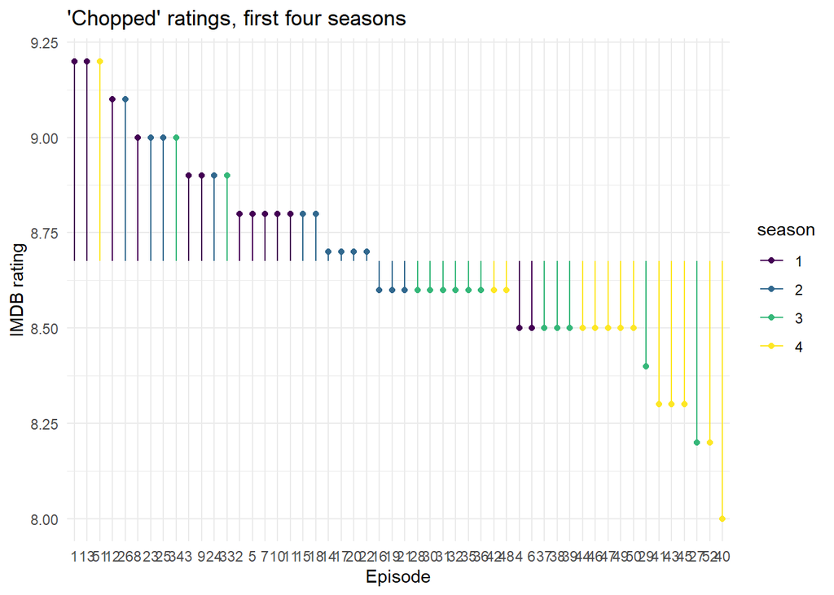

```r
chopped %>%
  filter(season %in% c("1", "2", "3", "4")) %>%
  ggplot() +
  aes(x = reorder(series_episode, -episode_rating),
      y = episode_rating,
      colour = season) +
  scale_color_viridis(discrete = TRUE) + #optional, just to change colours
  geom_point() +
  geom_segment(aes(x = series_episode, xend = series_episode,
                   y = mean(episode_rating), yend = episode_rating)
               ) +
  theme_minimal() +
  labs(x = "Episode",
       y = "IMDB rating",
       title = "'Chopped' ratings, first four seasons")
```

Because I’ve put the colour = season argument into the general aesthetics argument, both the dots and the stems are coloured, but I can specifically put it into either geom_point (to colour the dots) or geom_segment (to colour the lines).

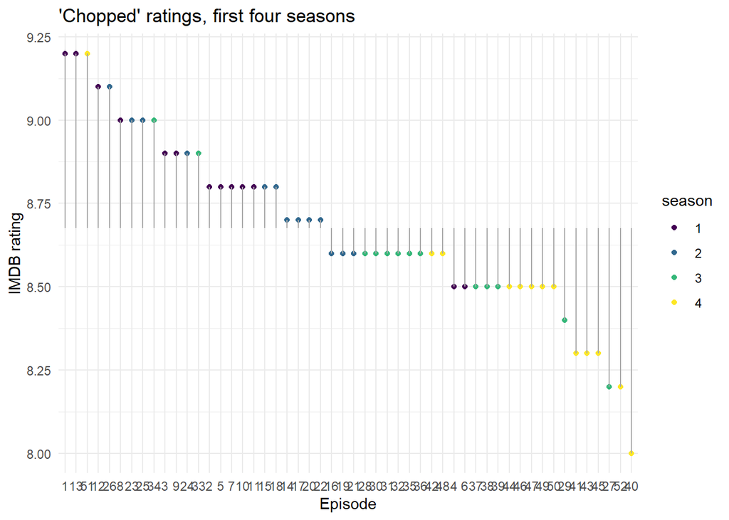

```r
chopped %>%
  filter(season %in% c("1", "2", "3", "4")) %>%
  ggplot() +
  aes(x = reorder(series_episode, -episode_rating),
      y = episode_rating,
      ) +
  scale_color_viridis(discrete = TRUE) + #optional, just to change colours
  geom_point(aes(colour = season)) +
  geom_segment(aes(x = series_episode, xend = series_episode,
                   y = mean(episode_rating), yend = episode_rating),
               colour = "darkgray" # all stems are gray
               ) +
  theme_minimal() +
  labs(x = "Episode",
       y = "IMDB rating",
       title = "'Chopped' ratings, first four seasons")
```

Or we can set the colours to show the IMDB ratings:

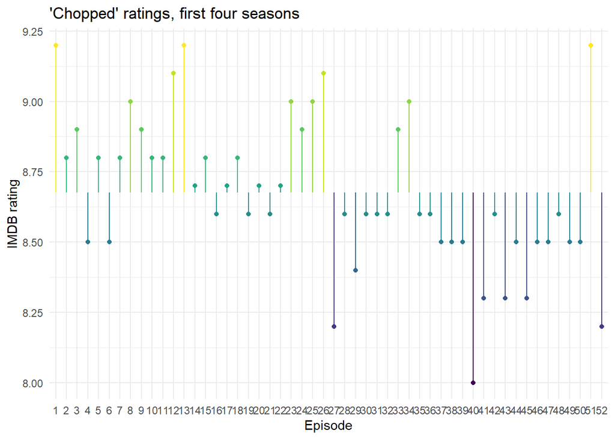

```r
chopped %>%
  filter(season %in% c("1", "2", "3", "4")) %>%
  ggplot() +
  aes(x = series_episode,
      y = episode_rating,
      colour = episode_rating) +
  scale_color_viridis() + #optional, just to change colours
  geom_point() +
  geom_segment(aes(x = series_episode, xend = series_episode,
                   y = mean(episode_rating), yend = episode_rating)
               ) +
  theme_minimal() +
  labs(x = "Episode",
       y = "IMDB rating",
       title = "'Chopped' ratings, first four seasons") +
  theme(legend.position = "none") # remove the legend
```

## Changing the size

Let’s also map episode ratings on the size of the dots, and change the size of the lines.

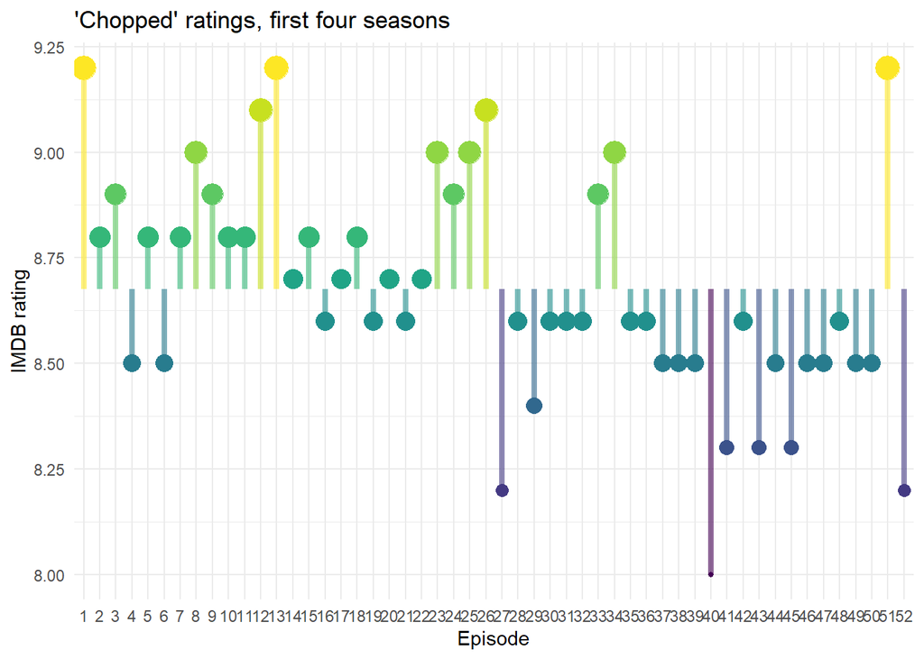

```r
chopped %>%
  filter(season %in% c("1", "2", "3", "4")) %>%
  ggplot() +
  aes(x = series_episode,
      y = episode_rating,
      colour = episode_rating) +
  scale_color_viridis() + #optional, just to change colours
  geom_point(aes(size = episode_rating)) +
  geom_segment(aes(x = series_episode, xend = series_episode,
                   y = mean(episode_rating), yend = episode_rating),
               size = 1.5, alpha = 0.6 #this changes the size of the lines and their transparency
               ) +
  theme_minimal() +
  labs(x = "Episode",
       y = "IMDB rating",
       title = "'Chopped' ratings, first four seasons") +
  theme(legend.position = "none") # remove the legend
```

## Customising stems and markers

For the dots, shape = can be used to either map a variable, e.g. season…

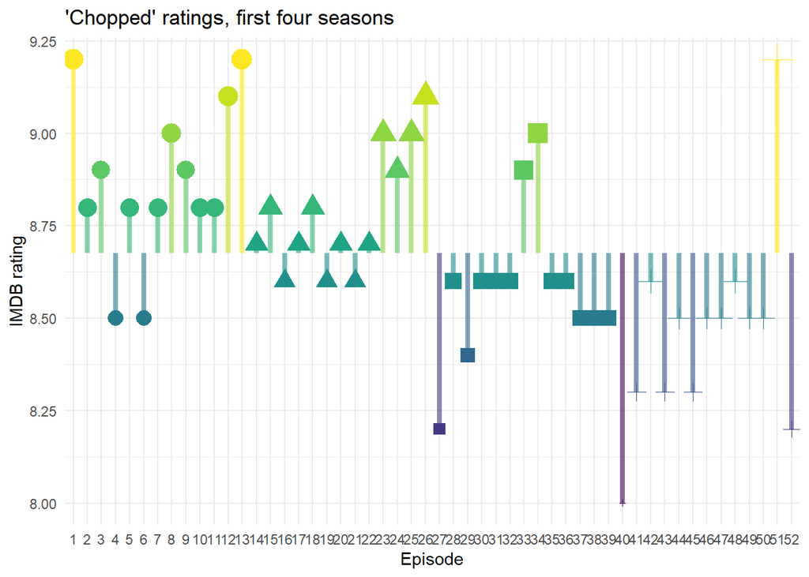

```r
chopped %>%
  filter(season %in% c("1", "2", "3", "4")) %>%
  ggplot() +
  aes(x = series_episode,
      y = episode_rating,
      colour = episode_rating) +
  scale_color_viridis() + #optional, just to change colours
  geom_point(aes(size = episode_rating, shape = season)) +
  geom_segment(aes(x = series_episode, xend = series_episode,
                   y = mean(episode_rating), yend = episode_rating),
               size = 1.5, alpha = 0.6
               ) +
  theme_minimal() +
  labs(x = "Episode",
       y = "IMDB rating",
       title = "'Chopped' ratings, first four seasons") +
  theme(legend.position = "none") # remove the legend
```

…or we can use the same shape for all markers:

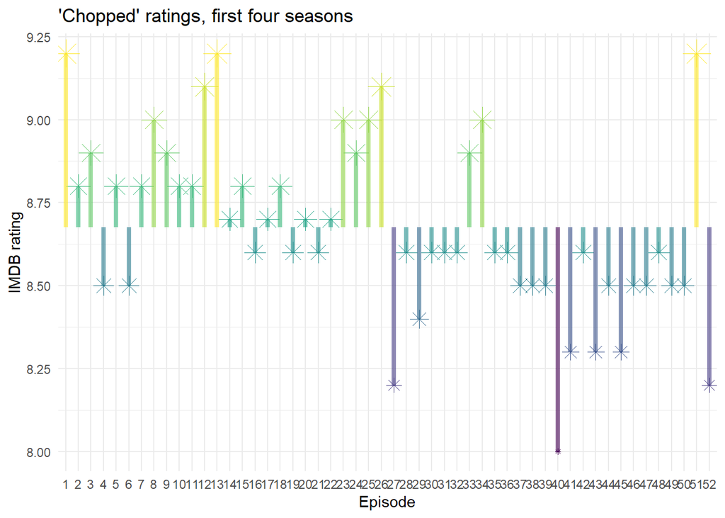

```r
chopped %>%
  filter(season %in% c("1", "2", "3", "4")) %>%
  ggplot() +
  aes(x = series_episode,
      y = episode_rating,
      colour = episode_rating) +
  scale_color_viridis() + # optional, just to change colours
  geom_point(aes(size = episode_rating), shape = 8) +
  geom_segment(aes(x = series_episode, xend = series_episode,
                   y = mean(episode_rating), yend = episode_rating),
               size = 1.5, alpha = 0.6,
               ) +
  theme_minimal() +
  labs(x = "Episode",
       y = "IMDB rating",
       title = "'Chopped' ratings, first four seasons") +
  theme(legend.position = "none") # remove the legend
```

Here’s an overview of available shapes:

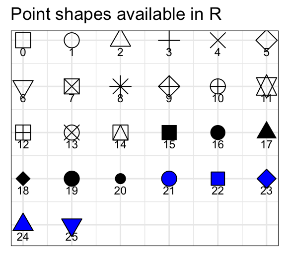

The lines can be changed, too:

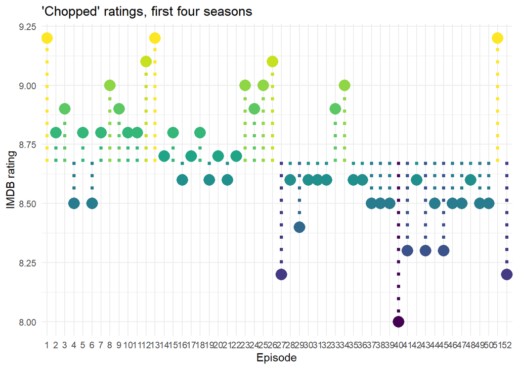

```r
chopped %>%
  filter(season %in% c("1", "2", "3", "4")) %>%
  ggplot() +
  aes(x = series_episode,
      y = episode_rating,
      colour = episode_rating) +
  scale_color_viridis() + #optional, just to change colours
  geom_point(size = 5) +
  geom_segment(aes(x = series_episode, xend = series_episode,
                   y = mean(episode_rating), yend = episode_rating),
               size = 1.5, linetype = "dotted"
               ) +
  theme_minimal() +
  labs(x = "Episode",
       y = "IMDB rating",
       title = "'Chopped' ratings, first four seasons") +
  theme(legend.position = "none")
```

Here’s an overview of available line types:

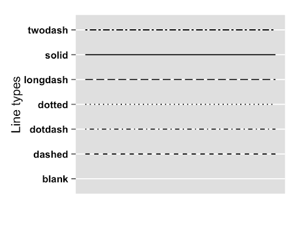

## Cleveland dot plots

…are offshoots of lollipop plots to compare two values for several groups. To show this, let’s first create a new data frame that contains three columns: the episode, the rating for that episode in season 1, and the rating for the corresponding episode in season 2.

```r
comp <- chopped %>%
  filter(season %in% c("1", "2")) %>%
  select(season, season_episode, episode_rating) %>%
  pivot_wider(names_from = season, values_from = episode_rating) %>%
  rename("season_1" = "1",
         "season_2" = "2") %>%
  mutate(season_episode = as_factor(season_episode))

head(comp)
```

```
## # A tibble: 6 x 3
##   season_episode season_1 season_2
##   <fct>             <dbl>    <dbl>
## 1 1                   9.2      8.7
## 2 2                   8.8      8.8
## 3 3                   8.9      8.6
## 4 4                   8.5      8.7
## 5 5                   8.8      8.8
## 6 6                   8.5      8.6
```

Compared to a lollipop plot, we need to draw a second set of dots and connect these with lines. We also have to manually set the colours.

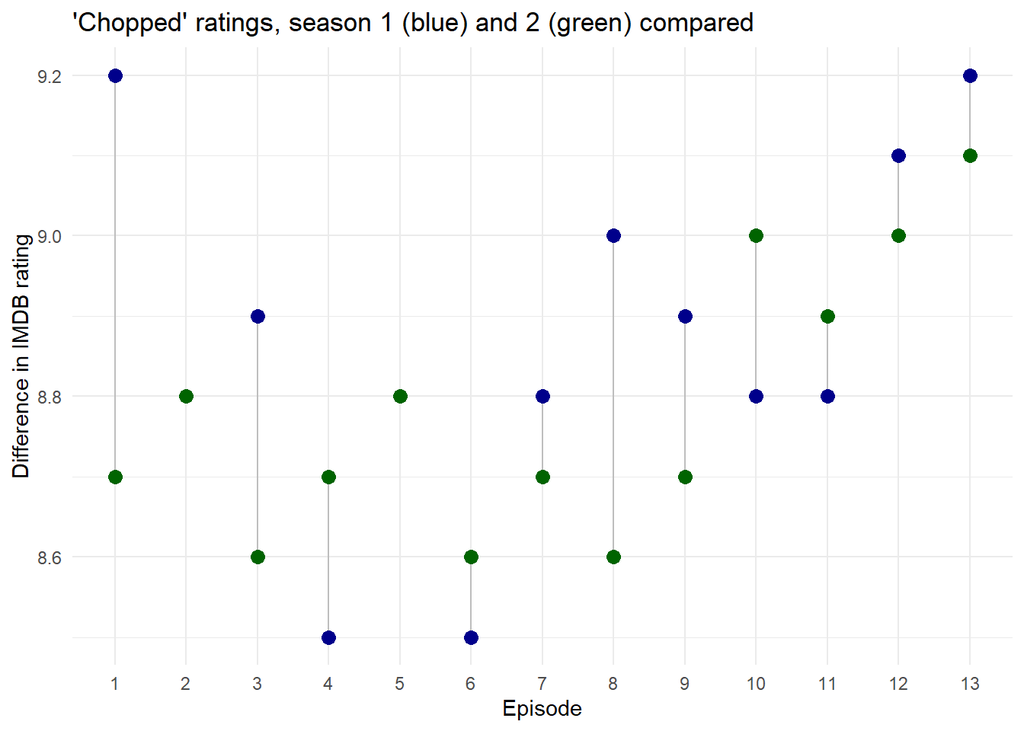

```r
comp %>%
  ggplot() +
  aes(x = season_episode) +
  geom_segment(aes(xend=season_episode,
                   y=season_1, yend=season_2),
               color="grey") +
  geom_point(aes(y = season_1),
             size = 3, colour = "darkblue") +
  geom_point(aes(y = season_2),
             size = 3, colour = "darkgreen") +
  theme_minimal() +
  labs(x = "Episode",
       y = "Difference in IMDB rating",
       title = "'Chopped' ratings, season 1 (blue) and 2 (green) compared")
```